# Topic 8 Exercises: Tree-based models

# programming: 8.4.12

Apply boosting, bagging, and random forests to a data set of your choice. Be sure to fit the models on a training set and to evaluate their performance on a test set. How accurate are the results compared to simple methods like linear or logistic regression? Which of these approaches yields the best performance?

For all, I will be using 5 predictors with the model form:

wage_binom2~age+year+maritl+education+health_in

which are the top 5 predictors I got looking at importance values in RandomForest I will calculate error rates using this model using logistic regression, boosting, bagging, and random forest.

```r
mod_log<-glm(wage_binom3~age+year+maritl+education+health_ins,data=train,family="binomial")
log_out_sample<-predict(mod_log,newdata=test,type="response")
log_pred<-ifelse(log_out_sample>=.5,1,0)
b<-table(test$wage_binom3,log_pred)
log_err<-(b[2,1]+b[1,2])/(b[1,2]+b[2,1]+b[1,1]+b[2,2])
b
```

```
##    log_pred
##       0   1
##   0 427 252
##   1 167 654
```

```r
log_err
```

```
## [1] 0.2793333
```

Boosting: error is .29

```r
mod_boost<-gbm(wage_binom3~age+year+maritl+education+health_ins,data=train,n.trees=5000)
```

```
## Distribution not specified, assuming bernoulli ...
```

```r
boost_out_sample<-predict(mod_boost,newdata=test,n.trees=5000)
boost_pred<-ifelse(boost_out_sample>=.5,1,0)
b<-table(test$wage_binom3,boost_pred)
boost_err<-(b[2,1]+b[1,2])/(b[1,2]+b[2,1]+b[1,1]+b[2,2])
b
```

```
##    boost_pred
##       0   1
##   0 527 152
##   1 297 524
```

```r
boost_err
```

```
## [1] 0.2993333
```

```r
mod_bag<-rpart(wage_binom3~age+year+maritl+education+health_ins,data=train)
bag_out_sample<-predict(mod_bag,newdata=test)
bag_pred<-ifelse(bag_out_sample>=.5,1,0)

b<-table(test$wage_binom3, bag_pred)
bag_err<-(b[2,1]+b[1,2])/(b[1,2]+b[2,1]+b[1,1]+b[2,2])
bag_err
```

```
## [1] 0.3006667
```

```r
mod_forest<-randomForest(wage_binom2~age+year+maritl+education+health_ins,data=train)
forest_out_sample <- predict(mod_forest, newdata = test)
b<-table(test$wage_binom2, forest_out_sample)
rf_err<-(b[2,1]+b[1,2])/(b[1,2]+b[2,1]+b[1,1]+b[2,2])
rf_err
```

```
## [1] 0.2906667
```

Boosting: error is .29

# theory: In §8.4 problems 1, 2, 3, 4, and 5

# 1

Draw an example (of your own invention) of a partition of twodimensional feature space that could result from recursive binary splitting. Your example should contain at least six regions. Draw a decision tree corresponding to this partition. Be sure to label all aspects of your figures, including the regions R1, R2,…, the cutpoints t1, t2,…, and so forth.

Hint: Your result should look something like Figures 8.1 and 8.2

**I did this by hand…I would be more than happy to show it to you or take a picture and email it**

# 2

It is mentioned in Section 8.2.3 that boosting using depth-one trees (or stumps) leads to an additive model… Explain why this is the case. You can begin with (8.12) in Algorithm 8.2.

Boosting improves the predictions from a decision true by ‘growing’ trees sequentially, so that each new tree involves information from all the previous trees. The tree is fitted slowly, but it is additive.Boosting classification trees relies on three parameters, the number of trees (B), the the shrinkage parameter (lambda), and the number of splits ( d, or interaction depth).

Boosting with depth-one trees leads to an additive model because you are including multiple trees, each with depth-one, in the final model. Even if d=1, you can still tune the number of trees produced (B) as well as the strictness (lambda) so that you are adding to your model each time you go through the algorithm.

# 3

Consider the Gini index, classification error, and cross-entropy in a simple classification setting with two classes. Create a single plot that displays each of these quantities as a function of ˆpm1. The xaxis should display ˆpm1, ranging from 0 to 1, and the y-axis should display the value of the Gini index, classification error, and entropy.

Hint: In a setting with two classes, pˆm1 = 1 − pˆm2. You could make this plot by hand, but it will be much easier to make in R.

pm1: prportoon of training observations in the mth region in the first class

```r
pmk<-seq(0,1,.01)

  gini<-((pmk*(1-pmk))+((1-pmk)*(pmk)))
  class_err<-(1-pmax(pmk,1-pmk))
  entropy<-(-((pmk*log(pmk))+(1-pmk)*log(1-pmk)))
```

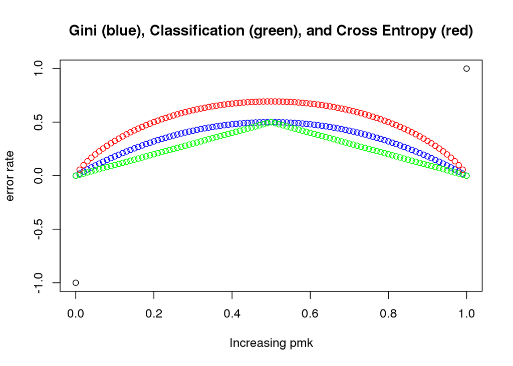

```r
plot(x=c(0,1),y=c(-1,1),xlab="Increasing pmk", ylab="error rate", main="Gini (blue), Classification (green), and Cross Entropy (red)")
points(x=pmk,y=gini,col="blue")
points(x=pmk,y=class_err,col="green")
points(x=pmk,y=entropy,col="red")
```

If my graph is correct, than it seems that all three have highest error rates for relativlely euqal class distributions, which isn’t too surprising. It also seems that the classification error rate is outperforming the other two for this very simplified case and that the cross entropy has a higher error than the gini coefficiebt. Likewise the gini and cross-entropy are both parabolic, while the classification error has a sharp point in the middle.

# 4

This question relates to the plots in Figure 8.12. (a) Sketch the tree corresponding to the partition of the predictor space illustrated in the left-hand panel of Figure 8.12. The numbers inside the boxes indicate the mean of Y within each region.

**This is on a notebook page, again would be happy to send a photo if needed. Its a very left skewed tree.**

2. Create a diagram similar to the left-hand panel of Figure 8.12, using the tree illustrated in the right-hand panel of the same figure. You should divide up the predictor space into the correct regions, and indicate the mean for each region.

**Same notebook, same page! Happy to email it!**

# 5

There are two common ways to combine these results together into a single class prediction. One is the majority vote approach discussed in this chapter. The second approach is to classify based on the average probability. In this example, what is the final classification under each of these two approaches?

```r
p<-c(0.1, 0.15, 0.2, 0.2, 0.55, 0.6, 0.6, 0.65, 0.7, 0.75)

maj_vote<-ifelse(p>.5,1,0)
maj_vote_method<-sum(maj_vote)/length(maj_vote)

avg_method<-sum(p)/length(p)

print(maj_vote_method)
```

```
## [1] 0.6
```

```r
print(avg_method)
```

```
## [1] 0.45
```

The majority vote method would classify it as red, and the average probability method would classify as green